# Risk Factor Analysis

## Outcome Variable

**Outcome Variable:** ever_stunted

## Predictor Variables

**Intervention Variable:** fhtcm

**Adjustment Set:**

unadjusted

## Stratifying Variables

The analysis was stratified on these variable(s):

- agecat
- studyid
- country

## Data Summary

| agecat | studyid | country | A | n | nA | nAY0 | nAY1 |
| --- | --- | --- | --- | --- | --- | --- | --- |
| 3 months | ki1101329-Keneba | GAMBIA | [160-170) | 1647 | 899 | 664 | 235 |
| 3 months | ki1101329-Keneba | GAMBIA | <160 | 1647 | 37 | 26 | 11 |
| 3 months | ki1101329-Keneba | GAMBIA | >=170 | 1647 | 711 | 567 | 144 |
| 3 months | ki1135781-COHORTS | GUATEMALA | [160-170) | 150 | 80 | 58 | 22 |
| 3 months | ki1135781-COHORTS | GUATEMALA | <160 | 150 | 57 | 29 | 28 |
| 3 months | ki1135781-COHORTS | GUATEMALA | >=170 | 150 | 13 | 7 | 6 |
| 6 months | ki1000304b-SAS-FoodSuppl | INDIA | [160-170) | 100 | 64 | 43 | 21 |
| 6 months | ki1000304b-SAS-FoodSuppl | INDIA | <160 | 100 | 25 | 11 | 14 |
| 6 months | ki1000304b-SAS-FoodSuppl | INDIA | >=170 | 100 | 11 | 6 | 5 |
| 6 months | ki1101329-Keneba | GAMBIA | [160-170) | 1609 | 888 | 576 | 312 |
| 6 months | ki1101329-Keneba | GAMBIA | <160 | 1609 | 35 | 20 | 15 |
| 6 months | ki1101329-Keneba | GAMBIA | >=170 | 1609 | 686 | 500 | 186 |
| 12 months | ki1000304b-SAS-FoodSuppl | INDIA | [160-170) | 97 | 61 | 9 | 52 |
| 12 months | ki1000304b-SAS-FoodSuppl | INDIA | <160 | 97 | 25 | 3 | 22 |
| 12 months | ki1000304b-SAS-FoodSuppl | INDIA | >=170 | 97 | 11 | 2 | 9 |
| 12 months | ki1101329-Keneba | GAMBIA | [160-170) | 1687 | 928 | 499 | 429 |
| 12 months | ki1101329-Keneba | GAMBIA | <160 | 1687 | 36 | 17 | 19 |
| 12 months | ki1101329-Keneba | GAMBIA | >=170 | 1687 | 723 | 462 | 261 |
| 12 months | ki1135781-COHORTS | GUATEMALA | [160-170) | 208 | 115 | 27 | 88 |
| 12 months | ki1135781-COHORTS | GUATEMALA | <160 | 208 | 79 | 12 | 67 |
| 12 months | ki1135781-COHORTS | GUATEMALA | >=170 | 208 | 14 | 3 | 11 |
| 18 months | ki1000304b-SAS-FoodSuppl | INDIA | [160-170) | 92 | 58 | 5 | 53 |
| 18 months | ki1000304b-SAS-FoodSuppl | INDIA | <160 | 92 | 25 | 4 | 21 |
| 18 months | ki1000304b-SAS-FoodSuppl | INDIA | >=170 | 92 | 9 | 0 | 9 |
| 18 months | ki1101329-Keneba | GAMBIA | [160-170) | 1644 | 912 | 391 | 521 |
| 18 months | ki1101329-Keneba | GAMBIA | <160 | 1644 | 34 | 12 | 22 |
| 18 months | ki1101329-Keneba | GAMBIA | >=170 | 1644 | 698 | 386 | 312 |
| 18 months | ki1135781-COHORTS | GUATEMALA | [160-170) | 175 | 98 | 15 | 83 |
| 18 months | ki1135781-COHORTS | GUATEMALA | <160 | 175 | 64 | 6 | 58 |
| 18 months | ki1135781-COHORTS | GUATEMALA | >=170 | 175 | 13 | 2 | 11 |
| 24 months | ki1000304b-SAS-FoodSuppl | INDIA | [160-170) | 9 | 5 | 1 | 4 |
| 24 months | ki1000304b-SAS-FoodSuppl | INDIA | <160 | 9 | 2 | 0 | 2 |
| 24 months | ki1000304b-SAS-FoodSuppl | INDIA | >=170 | 9 | 2 | 0 | 2 |
| 24 months | ki1101329-Keneba | GAMBIA | [160-170) | 1611 | 904 | 323 | 581 |
| 24 months | ki1101329-Keneba | GAMBIA | <160 | 1611 | 34 | 9 | 25 |
| 24 months | ki1101329-Keneba | GAMBIA | >=170 | 1611 | 673 | 330 | 343 |
| 24 months | ki1135781-COHORTS | GUATEMALA | [160-170) | 213 | 120 | 9 | 111 |
| 24 months | ki1135781-COHORTS | GUATEMALA | <160 | 213 | 78 | 7 | 71 |
| 24 months | ki1135781-COHORTS | GUATEMALA | >=170 | 213 | 15 | 3 | 12 |

The following strata were considered:

- agecat: 12 months, studyid: ki1000304b-SAS-FoodSuppl, country: INDIA
- agecat: 12 months, studyid: ki1101329-Keneba, country: GAMBIA
- agecat: 12 months, studyid: ki1135781-COHORTS, country: GUATEMALA
- agecat: 18 months, studyid: ki1000304b-SAS-FoodSuppl, country: INDIA
- agecat: 18 months, studyid: ki1101329-Keneba, country: GAMBIA
- agecat: 18 months, studyid: ki1135781-COHORTS, country: GUATEMALA
- agecat: 24 months, studyid: ki1000304b-SAS-FoodSuppl, country: INDIA
- agecat: 24 months, studyid: ki1101329-Keneba, country: GAMBIA
- agecat: 24 months, studyid: ki1135781-COHORTS, country: GUATEMALA
- agecat: 3 months, studyid: ki1101329-Keneba, country: GAMBIA
- agecat: 3 months, studyid: ki1135781-COHORTS, country: GUATEMALA
- agecat: 6 months, studyid: ki1000304b-SAS-FoodSuppl, country: INDIA
- agecat: 6 months, studyid: ki1101329-Keneba, country: GAMBIA

### Dropped Strata

Some strata were dropped due to rare outcomes:

- agecat: 12 months, studyid: ki1000304b-SAS-FoodSuppl, country: INDIA
- agecat: 12 months, studyid: ki1135781-COHORTS, country: GUATEMALA
- agecat: 18 months, studyid: ki1000304b-SAS-FoodSuppl, country: INDIA
- agecat: 18 months, studyid: ki1135781-COHORTS, country: GUATEMALA
- agecat: 24 months, studyid: ki1000304b-SAS-FoodSuppl, country: INDIA
- agecat: 24 months, studyid: ki1135781-COHORTS, country: GUATEMALA

## Methods Detail

We’re interested in the causal parameters $E[Y_a]$ for all values of $a \in \mathcal{A}$. These parameters represent the mean outcome if, possibly contrary to fact, we intervened to set all units to have $A=a$. Under the randomization and positivity assumptions, these are identified by the statistical parameters $\psi_a=E_W[E_{Y|A,W}(Y|A=a,W)]$. In addition, we’re interested in the mean of $Y$, $E[Y]$ under no intervention (the observed mean). We will estimate these parameters by using SuperLearner to fit the relevant likelihood factors – $E_{Y|A,W}(Y|A=a,W)$ and $p(A=a|W)$, and then updating our likelihood fit using a joint TMLE.

For unadjusted analyses ($W=\{\}$), initial likelihoods were estimated using Lrnr_glm to estimate the simple $E(Y|A)$ and Lrnr_mean to estimate $p(A)$. For adjusted analyses, a small library containing Lrnr_glmnet, Lrnr_xgboost, and Lrnr_mean was used.

Having estimated these parameters, we will then use the delta method to estimate relative risks and attributable risks relative to a prespecified baseline level of $A$.

# Results Detail

## Results Plots

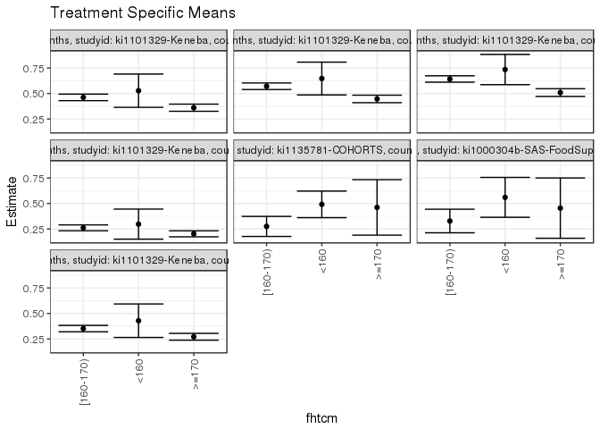

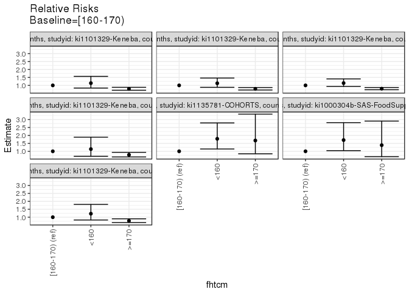

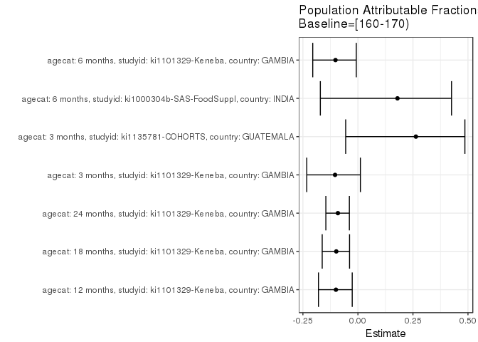

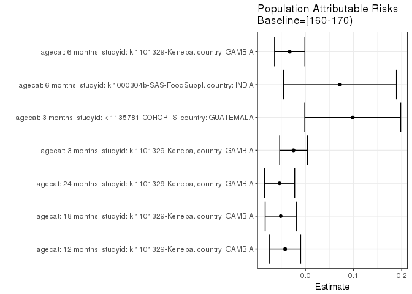

## Results Table

### Parameter: TSM

| agecat | studyid | country | intervention_level | baseline_level | estimate | ci_lower | ci_upper |
| --- | --- | --- | --- | --- | --- | --- | --- |
| 3 months | ki1101329-Keneba | GAMBIA | [160-170) | NA | 0.2614016 | 0.2326701 | 0.2901331 |
| 3 months | ki1101329-Keneba | GAMBIA | <160 | NA | 0.2972973 | 0.1499777 | 0.4446169 |
| 3 months | ki1101329-Keneba | GAMBIA | >=170 | NA | 0.2025316 | 0.1729823 | 0.2320810 |
| 3 months | ki1135781-COHORTS | GUATEMALA | [160-170) | NA | 0.2750000 | 0.1768273 | 0.3731727 |
| 3 months | ki1135781-COHORTS | GUATEMALA | <160 | NA | 0.4912281 | 0.3610115 | 0.6214447 |
| 3 months | ki1135781-COHORTS | GUATEMALA | >=170 | NA | 0.4615385 | 0.1896378 | 0.7334391 |
| 6 months | ki1000304b-SAS-FoodSuppl | INDIA | [160-170) | NA | 0.3281250 | 0.2125126 | 0.4437374 |
| 6 months | ki1000304b-SAS-FoodSuppl | INDIA | <160 | NA | 0.5600000 | 0.3644396 | 0.7555604 |
| 6 months | ki1000304b-SAS-FoodSuppl | INDIA | >=170 | NA | 0.4545455 | 0.1588109 | 0.7502800 |
| 6 months | ki1101329-Keneba | GAMBIA | [160-170) | NA | 0.3513514 | 0.3199425 | 0.3827602 |
| 6 months | ki1101329-Keneba | GAMBIA | <160 | NA | 0.4285714 | 0.2645723 | 0.5925706 |
| 6 months | ki1101329-Keneba | GAMBIA | >=170 | NA | 0.2711370 | 0.2378605 | 0.3044136 |
| 12 months | ki1101329-Keneba | GAMBIA | [160-170) | NA | 0.4622845 | 0.4301971 | 0.4943718 |
| 12 months | ki1101329-Keneba | GAMBIA | <160 | NA | 0.5277778 | 0.3646513 | 0.6909042 |
| 12 months | ki1101329-Keneba | GAMBIA | >=170 | NA | 0.3609959 | 0.3259763 | 0.3960154 |
| 18 months | ki1101329-Keneba | GAMBIA | [160-170) | NA | 0.5712719 | 0.5391431 | 0.6034008 |
| 18 months | ki1101329-Keneba | GAMBIA | <160 | NA | 0.6470588 | 0.4863781 | 0.8077396 |
| 18 months | ki1101329-Keneba | GAMBIA | >=170 | NA | 0.4469914 | 0.4100964 | 0.4838864 |
| 24 months | ki1101329-Keneba | GAMBIA | [160-170) | NA | 0.6426991 | 0.6114513 | 0.6739469 |
| 24 months | ki1101329-Keneba | GAMBIA | <160 | NA | 0.7352941 | 0.5869550 | 0.8836333 |
| 24 months | ki1101329-Keneba | GAMBIA | >=170 | NA | 0.5096582 | 0.4718780 | 0.5474385 |

### Parameter: E(Y)

| agecat | studyid | country | intervention_level | baseline_level | estimate | ci_lower | ci_upper |
| --- | --- | --- | --- | --- | --- | --- | --- |
| 3 months | ki1101329-Keneba | GAMBIA | NA | NA | 0.2367942 | 0.2353292 | 0.2382591 |
| 3 months | ki1135781-COHORTS | GUATEMALA | NA | NA | 0.3733333 | 0.3564067 | 0.3902600 |
| 6 months | ki1000304b-SAS-FoodSuppl | INDIA | NA | NA | 0.4000000 | 0.3802686 | 0.4197314 |
| 6 months | ki1101329-Keneba | GAMBIA | NA | NA | 0.3188316 | 0.3167490 | 0.3209141 |
| 12 months | ki1101329-Keneba | GAMBIA | NA | NA | 0.4202727 | 0.4177817 | 0.4227637 |
| 18 months | ki1101329-Keneba | GAMBIA | NA | NA | 0.5200730 | 0.5169938 | 0.5231522 |
| 24 months | ki1101329-Keneba | GAMBIA | NA | NA | 0.5890751 | 0.5857265 | 0.5924237 |

### Parameter: RR

| agecat | studyid | country | intervention_level | baseline_level | estimate | ci_lower | ci_upper |
| --- | --- | --- | --- | --- | --- | --- | --- |
| 3 months | ki1101329-Keneba | GAMBIA | [160-170) | [160-170) | 1.0000000 | 1.0000000 | 1.0000000 |
| 3 months | ki1101329-Keneba | GAMBIA | <160 | [160-170) | 1.1373203 | 0.6846154 | 1.8893784 |
| 3 months | ki1101329-Keneba | GAMBIA | >=170 | [160-170) | 0.7747913 | 0.6454355 | 0.9300721 |
| 3 months | ki1135781-COHORTS | GUATEMALA | [160-170) | [160-170) | 1.0000000 | 1.0000000 | 1.0000000 |
| 3 months | ki1135781-COHORTS | GUATEMALA | <160 | [160-170) | 1.7862839 | 1.1450962 | 2.7864997 |
| 3 months | ki1135781-COHORTS | GUATEMALA | >=170 | [160-170) | 1.6783217 | 0.8427814 | 3.3422232 |
| 6 months | ki1000304b-SAS-FoodSuppl | INDIA | [160-170) | [160-170) | 1.0000000 | 1.0000000 | 1.0000000 |
| 6 months | ki1000304b-SAS-FoodSuppl | INDIA | <160 | [160-170) | 1.7066667 | 1.0392104 | 2.8028118 |
| 6 months | ki1000304b-SAS-FoodSuppl | INDIA | >=170 | [160-170) | 1.3852814 | 0.6610056 | 2.9031593 |
| 6 months | ki1101329-Keneba | GAMBIA | [160-170) | [160-170) | 1.0000000 | 1.0000000 | 1.0000000 |
| 6 months | ki1101329-Keneba | GAMBIA | <160 | [160-170) | 1.2197802 | 0.8234133 | 1.8069466 |
| 6 months | ki1101329-Keneba | GAMBIA | >=170 | [160-170) | 0.7716977 | 0.6629885 | 0.8982318 |
| 12 months | ki1101329-Keneba | GAMBIA | [160-170) | [160-170) | 1.0000000 | 1.0000000 | 1.0000000 |
| 12 months | ki1101329-Keneba | GAMBIA | <160 | [160-170) | 1.1416731 | 0.8316990 | 1.5671746 |
| 12 months | ki1101329-Keneba | GAMBIA | >=170 | [160-170) | 0.7808955 | 0.6930890 | 0.8798260 |
| 18 months | ki1101329-Keneba | GAMBIA | [160-170) | [160-170) | 1.0000000 | 1.0000000 | 1.0000000 |
| 18 months | ki1101329-Keneba | GAMBIA | <160 | [160-170) | 1.1326634 | 0.8780585 | 1.4610944 |
| 18 months | ki1101329-Keneba | GAMBIA | >=170 | [160-170) | 0.7824494 | 0.7080744 | 0.8646367 |
| 24 months | ki1101329-Keneba | GAMBIA | [160-170) | [160-170) | 1.0000000 | 1.0000000 | 1.0000000 |
| 24 months | ki1101329-Keneba | GAMBIA | <160 | [160-170) | 1.1440721 | 0.9296721 | 1.4079168 |
| 24 months | ki1101329-Keneba | GAMBIA | >=170 | [160-170) | 0.7929967 | 0.7257231 | 0.8665064 |

### Parameter: PAR

| agecat | studyid | country | intervention_level | baseline_level | estimate | ci_lower | ci_upper |
| --- | --- | --- | --- | --- | --- | --- | --- |
| 3 months | ki1101329-Keneba | GAMBIA | [160-170) | NA | -0.0246074 | -0.0533762 | 0.0041614 |
| 3 months | ki1135781-COHORTS | GUATEMALA | [160-170) | NA | 0.0983333 | -0.0012879 | 0.1979546 |
| 6 months | ki1000304b-SAS-FoodSuppl | INDIA | [160-170) | NA | 0.0718750 | -0.0454091 | 0.1891591 |
| 6 months | ki1101329-Keneba | GAMBIA | [160-170) | NA | -0.0325198 | -0.0639976 | -0.0010420 |
| 12 months | ki1101329-Keneba | GAMBIA | [160-170) | NA | -0.0420118 | -0.0741957 | -0.0098279 |
| 18 months | ki1101329-Keneba | GAMBIA | [160-170) | NA | -0.0511989 | -0.0834750 | -0.0189229 |
| 24 months | ki1101329-Keneba | GAMBIA | [160-170) | NA | -0.0536240 | -0.0850507 | -0.0221973 |

### Parameter: PAF

| agecat | studyid | country | intervention_level | baseline_level | estimate | ci_lower | ci_upper |
| --- | --- | --- | --- | --- | --- | --- | --- |
| 3 months | ki1101329-Keneba | GAMBIA | [160-170) | NA | -0.1039189 | -0.2323880 | 0.0111581 |
| 3 months | ki1135781-COHORTS | GUATEMALA | [160-170) | NA | 0.2633929 | -0.0556523 | 0.4860144 |
| 6 months | ki1000304b-SAS-FoodSuppl | INDIA | [160-170) | NA | 0.1796875 | -0.1708253 | 0.4252664 |
| 6 months | ki1101329-Keneba | GAMBIA | [160-170) | NA | -0.1019967 | -0.2053338 | -0.0075191 |
| 12 months | ki1101329-Keneba | GAMBIA | [160-170) | NA | -0.0999632 | -0.1793221 | -0.0259446 |
| 18 months | ki1101329-Keneba | GAMBIA | [160-170) | NA | -0.0984457 | -0.1623547 | -0.0380505 |
| 24 months | ki1101329-Keneba | GAMBIA | [160-170) | NA | -0.0910308 | -0.1457665 | -0.0389101 |